# Alphabet Soup: Pandas problem

## A formatting challenge using Pandas dataframes

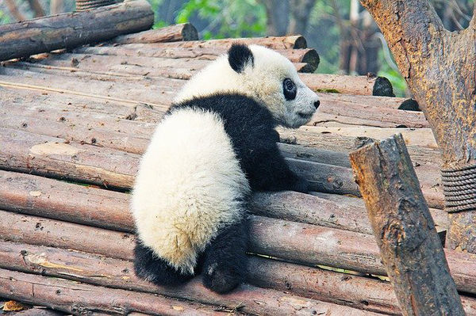

```python
from PIL import Image               # to load images
from IPython.display import display # to display images

basewidth = 600
pil_img = Image.open('assets/pandas_df.jpg')
wpercent = (basewidth/float(pil_img.size[0]))
hsize = int((float(pil_img.size[1])*float(wpercent)))
pil_img = pil_img.resize((basewidth,hsize), Image.ANTIALIAS)

display(pil_img)
```

Image by [Sharon Ang](https://pixabay.com/users/sharonang-99559/?utm_source=link-attribution&utm_medium=referral&utm_campaign=image&utm_content=1711000) from [Pixabay](https://pixabay.com/?utm_source=link-attribution&utm_medium=referral&utm_campaign=image&utm_content=1711000)

## Here's the Pandas problem:

A CSV report has been produced for the alphabet soup project: reports/alphabet_soup_sample_report.csv

However, there is a formatting problem with the file. When the sample report is read usineg the pandas dataframe, the last column - 'best_decrypted_word_dict' has been split accross several columns. The dataframe below illustrates the problem.

It can be seen that this has also resulted in the misallocation of the 14 column names for the pandas dataframe.

The task is to fix the formatting problems for the pandas dataframe and output the report to a CSV named 'alphabet_soup_sample_report_fixed.csv'.

**PLEASE NOTE**

Scrolling down reveals the **Solution** section, so please take case of spoilers!!

This primarily lists steps which can be followed as a holistic hint to solving the problem

```python
import pandas as pd

df = pd.read_csv("reports/alphabet_soup_sample_report.csv")
df.head()
```

|  |  |  |  |  |  |  |  |  | no_of_runs | mean_accuracy | standard_dev | median | word_decoder_max_epochs | word_finder_min_iters_per_epoch | word_finder_min_potential_words | word_finder_max_epochs | word_finder_max_attempts | no_of_random_letters | time_taken_in_seconds | word_finder_name | best_accuracy | best_decrypted_word_dict |
| --- | --- | --- | --- | --- | --- | --- | --- | --- | --- | --- | --- | --- | --- | --- | --- | --- | --- | --- | --- | --- | --- | --- |
| 150 | 28.866667 | 4.102163 | 30.0 | 75 | 50 | 5 | 3 | 3 | 0 | 438.690037 | TextBlobWordFinder | 40.0 | {'0ro0ec0': 'project' | '0ala00': 'galaxy' | '0e00est': 'request' | '0ra0e0': 'brazen' | '0o0ey': 'dovey' | 's00r0': 'swarm' | '0ebr0': 'kebre' | '0ri0t': 'lriit' | '00amy': 'foamy' | '0e00ry': 'sechry'} |
|  | 28.733333 | 4.062708 | 30.0 | 75 | 50 | 5 | 3 | 3 | 0 | 382.826677 | TextBlobWordFinder | 40.0 | {'0ala00': 'galaxy' | '0ro0ec0': 'project' | '0ra0e0': 'brazen' | '0e00est': 'request' | '0o0ey': 'dovey' | 's00r0': 'swarm' | '0ebr0': 'kebre' | '0ri0t': 'lriit' | '00amy': 'foamy' | '0e00ry': 'cehsry'} |
|  | 28.533333 | 4.394424 | 30.0 | 75 | 75 | 5 | 3 | 3 | 0 | 818.225044 | TextBlobWordFinder | 40.0 | {'0ro0ec0': 'project' | '0ala00': 'galaxy' | '0e00est': 'request' | '0ra0e0': 'brazen' | '0o0ey': 'dovey' | 's00r0': 'swarm' | '0ri0t': 'kriet' | '00amy': 'foamy' | '0ebr0': 'lebri' | '0e00ry': 'hecsry'} |
|  | 27.800000 | 4.758602 | 30.0 | 75 | 100 | 5 | 3 | 3 | 0 | 835.377826 | TextBlobWordFinder | 40.0 | {'0ala00': 'galaxy' | '0ro0ec0': 'project' | '0e00est': 'request' | '0ra0e0': 'brazen' | '0o0ey': 'dovey' | 's00r0': 'swarm' | '0ri0t': 'hriit' | '00amy': 'foamy' | '0ebr0': 'sebre' | '0e00ry': 'leckry'} |
|  | 28.266667 | 4.597441 | 30.0 | 75 | 125 | 5 | 3 | 3 | 0 | 1118.366127 | TextBlobWordFinder | 40.0 | {'0ala00': 'galaxy' | '0ro0ec0': 'project' | '0e00est': 'bequest' | '0o0ey': 'money' | 's00r0': 'shore' | '0ri0t': 'wrist' | '0ra0e0': 'draiea' | '0e00ry': 'zekvry' | '0ebr0': 'cebrf' | '00amy': 'rlamy'} |

## Here's the Solution:

Read on to see an in-depth approach which follows these steps to solve the problem.

### Step 1: Read the dataframe and check the datatypes for the columns

Please note the CSV is available here: reports/alphabet_soup_sample_report.csv

```
results_df = pd.read_csv("reports/alphabet_soup_sample_report.csv")
results_df.info()
```

```python
results_df = pd.read_csv("assets/alphabet_soup_sample_report.csv")
results_df.info()
```

```
<class 'pandas.core.frame.DataFrame'>
MultiIndex: 129 entries, (150, 28.86666666666667, 4.102162904148251, 30.0, 75, 50, 5, 3, 3) to (150, 22.26666666666667, 10.81551623820525, 20.0, 75, 0, 0, 0, 0)
Data columns (total 14 columns):
 #   Column                           Non-Null Count  Dtype
---  ------                           --------------  -----
 0   no_of_runs                       129 non-null    int64
 1   mean_accuracy                    129 non-null    float64
 2   standard_dev                     129 non-null    object
 3   median                           129 non-null    float64
 4   word_decoder_max_epochs          129 non-null    object
 5   word_finder_min_iters_per_epoch  129 non-null    object
 6   word_finder_min_potential_words  129 non-null    object
 7   word_finder_max_epochs           129 non-null    object
 8   word_finder_max_attempts         129 non-null    object
 9   no_of_random_letters             129 non-null    object
 10  time_taken_in_seconds            129 non-null    object
 11  word_finder_name                 129 non-null    object
 12  best_accuracy                    129 non-null    object
 13  best_decrypted_word_dict         129 non-null    object
dtypes: float64(2), int64(1), object(11)
memory usage: 17.3+ KB
```

#### Some considerations

First of all, we notice there's some multi-indexing for the columns and the columns stored as objects which show key-pair values should be stored as strings rather than objects. I discovered that technically, pandas dataframes should not be used as pointers to dictionaries, and really it is best suited for dealing with numeric data. An interesting discussion on this si avaialble on [stackoverflow](https://stackoverflow.com/questions/50731242/reading-pandas-dataframe-that-contains-dictionaries-in-cells-from-csv?rq=1).

Within my project, I did try to cast the dictionary object as a string before it was written to CSV. However, when the CSV was read by the pandas dataframe, the same splitting accross columns still occurred and the split parts were recognised as objects as a data type.

If storing thousands of records, I wouldn't store the word dictionary information. I captured it for the alphabet soup problem as it was at the heart of working towards solving the problem and visualising results. **Please note my understanding is that storing dictionaries with pandas dataframes is not good practice**, but in this instance, it provides an interesting formating problem to solve.

### Step 2: Store the column names in a variable called 'columns' for later use

```
columns = results_df.columns
columns
```

```python
columns = results_df.columns
columns
```

```
Index(['no_of_runs', 'mean_accuracy', 'standard_dev', 'median',
       'word_decoder_max_epochs', 'word_finder_min_iters_per_epoch',
       'word_finder_min_potential_words', 'word_finder_max_epochs',
       'word_finder_max_attempts', 'no_of_random_letters',
       'time_taken_in_seconds', 'word_finder_name', 'best_accuracy',
       'best_decrypted_word_dict'],
      dtype='object')
```

### Step 3: Convert the respective 'object' columns to string

```
results_df[["word_decoder_max_epochs", "word_finder_min_iters_per_epoch",
            "word_finder_min_potential_words", "word_finder_max_epochs",
            "word_finder_max_attempts", "no_of_random_letters", "time_taken_in_seconds",
            "word_finder_name", "best_accuracy", "best_decrypted_word_dict"]] =\
            results_df[["word_decoder_max_epochs", "word_finder_min_iters_per_epoch",
            "word_finder_min_potential_words", "word_finder_max_epochs",
            "word_finder_max_attempts", "no_of_random_letters", "time_taken_in_seconds",
            "word_finder_name", "best_accuracy", "best_decrypted_word_dict"]].astype('string')
results_df.info()
```

```python
results_df[["word_decoder_max_epochs", "word_finder_min_iters_per_epoch",
            "word_finder_min_potential_words", "word_finder_max_epochs",
            "word_finder_max_attempts", "no_of_random_letters", "time_taken_in_seconds",
           "word_finder_name", "best_accuracy", "best_decrypted_word_dict"]] = results_df[["word_decoder_max_epochs", "word_finder_min_iters_per_epoch",
            "word_finder_min_potential_words", "word_finder_max_epochs",
            "word_finder_max_attempts", "no_of_random_letters", "time_taken_in_seconds",
           "word_finder_name", "best_accuracy", "best_decrypted_word_dict"]].astype('string')
results_df.info()
```

```
<class 'pandas.core.frame.DataFrame'>
MultiIndex: 129 entries, (150, 28.86666666666667, 4.102162904148251, 30.0, 75, 50, 5, 3, 3) to (150, 22.26666666666667, 10.81551623820525, 20.0, 75, 0, 0, 0, 0)
Data columns (total 14 columns):
 #   Column                           Non-Null Count  Dtype
---  ------                           --------------  -----
 0   no_of_runs                       129 non-null    int64
 1   mean_accuracy                    129 non-null    float64
 2   standard_dev                     129 non-null    object
 3   median                           129 non-null    float64
 4   word_decoder_max_epochs          129 non-null    string
 5   word_finder_min_iters_per_epoch  129 non-null    string
 6   word_finder_min_potential_words  129 non-null    string
 7   word_finder_max_epochs           129 non-null    string
 8   word_finder_max_attempts         129 non-null    string
 9   no_of_random_letters             129 non-null    string
 10  time_taken_in_seconds            129 non-null    string
 11  word_finder_name                 129 non-null    string
 12  best_accuracy                    129 non-null    string
 13  best_decrypted_word_dict         129 non-null    string
dtypes: float64(2), int64(1), object(1), string(10)
memory usage: 17.3+ KB
```

```
results_df['best_decrypted_word_dict'] =\
            results_df[["word_decoder_max_epochs", "word_finder_min_iters_per_epoch",
                        "word_finder_min_potential_words", "word_finder_max_epochs",
                        "word_finder_max_attempts", "no_of_random_letters",
                        "time_taken_in_seconds","word_finder_name",
                        "best_accuracy", "best_decrypted_word_dict"]].agg(','.join,axis=1)
results_df["best_decrypted_word_dict"].astype('string')
results_df.info()
```

```python
results_df['best_decrypted_word_dict'] = results_df[["word_decoder_max_epochs", "word_finder_min_iters_per_epoch",
            "word_finder_min_potential_words", "word_finder_max_epochs",
            "word_finder_max_attempts", "no_of_random_letters", "time_taken_in_seconds",
           "word_finder_name", "best_accuracy", "best_decrypted_word_dict"]].agg(','.join, axis=1)
results_df["best_decrypted_word_dict"].astype('string')
results_df.info()
```

```
<class 'pandas.core.frame.DataFrame'>
MultiIndex: 129 entries, (150, 28.86666666666667, 4.102162904148251, 30.0, 75, 50, 5, 3, 3) to (150, 22.26666666666667, 10.81551623820525, 20.0, 75, 0, 0, 0, 0)
Data columns (total 14 columns):
 #   Column                           Non-Null Count  Dtype
---  ------                           --------------  -----
 0   no_of_runs                       129 non-null    int64
 1   mean_accuracy                    129 non-null    float64
 2   standard_dev                     129 non-null    object
 3   median                           129 non-null    float64
 4   word_decoder_max_epochs          129 non-null    string
 5   word_finder_min_iters_per_epoch  129 non-null    string
 6   word_finder_min_potential_words  129 non-null    string
 7   word_finder_max_epochs           129 non-null    string
 8   word_finder_max_attempts         129 non-null    string
 9   no_of_random_letters             129 non-null    string
 10  time_taken_in_seconds            129 non-null    string
 11  word_finder_name                 129 non-null    string
 12  best_accuracy                    129 non-null    string
 13  best_decrypted_word_dict         129 non-null    object
dtypes: float64(2), int64(1), object(2), string(9)
memory usage: 17.3+ KB
```

### Step 5: Drop the columns which are no longer needed and reset the column index

```
results_df.drop(["word_decoder_max_epochs", "word_finder_min_iters_per_epoch",
                 "word_finder_min_potential_words", "word_finder_max_epochs",
                 "word_finder_max_attempts", "no_of_random_letters", "time_taken_in_seconds",
                 "word_finder_name", "best_accuracy"], axis=1, inplace=True)

results_df.reset_index(inplace=True)
results_df.head()
```

```python
results_df.drop(["word_decoder_max_epochs", "word_finder_min_iters_per_epoch",
            "word_finder_min_potential_words", "word_finder_max_epochs",
            "word_finder_max_attempts", "no_of_random_letters", "time_taken_in_seconds",
           "word_finder_name", "best_accuracy"], axis=1, inplace=True)

results_df.reset_index(inplace=True)
results_df.head()
```

|  | level_0 | level_1 | level_2 | level_3 | level_4 | level_5 | level_6 | level_7 | level_8 | no_of_runs | mean_accuracy | standard_dev | median | best_decrypted_word_dict |
| --- | --- | --- | --- | --- | --- | --- | --- | --- | --- | --- | --- | --- | --- | --- |
| 0 | 150 | 28.866667 | 4.102163 | 30.0 | 75 | 50 | 5 | 3 | 3 | 0 | 438.690037 | TextBlobWordFinder | 40.0 | {'0ro0ec0': 'project', '0ala00': 'galaxy', '0e... |
| 1 | 150 | 28.733333 | 4.062708 | 30.0 | 75 | 50 | 5 | 3 | 3 | 0 | 382.826677 | TextBlobWordFinder | 40.0 | {'0ala00': 'galaxy', '0ro0ec0': 'project', '0r... |
| 2 | 150 | 28.533333 | 4.394424 | 30.0 | 75 | 75 | 5 | 3 | 3 | 0 | 818.225044 | TextBlobWordFinder | 40.0 | {'0ro0ec0': 'project', '0ala00': 'galaxy', '0e... |
| 3 | 150 | 27.800000 | 4.758602 | 30.0 | 75 | 100 | 5 | 3 | 3 | 0 | 835.377826 | TextBlobWordFinder | 40.0 | {'0ala00': 'galaxy', '0ro0ec0': 'project', '0e... |
| 4 | 150 | 28.266667 | 4.597441 | 30.0 | 75 | 125 | 5 | 3 | 3 | 0 | 1118.366127 | TextBlobWordFinder | 40.0 | {'0ala00': 'galaxy', '0ro0ec0': 'project', '0e... |

**Notice at this stage...**

- inplace = True is passed as an argument to ensure the changes are made to the dataframe object.
- Resetting the index means there's no longer a multi-index and we are left with 14 columns
- Pandas has provided default names e.g. level_0 etc. to those columns which don't immediately have a name

However, remember we stored the column names in variable. Thus...

### Step 6: Rename the columns and write to CSV

```
results_df.columns = columns
results_df.head()
```

```python
results_df.columns = columns
results_df.head()
```

|  | no_of_runs | mean_accuracy | standard_dev | median | word_decoder_max_epochs | word_finder_min_iters_per_epoch | word_finder_min_potential_words | word_finder_max_epochs | word_finder_max_attempts | no_of_random_letters | time_taken_in_seconds | word_finder_name | best_accuracy | best_decrypted_word_dict |
| --- | --- | --- | --- | --- | --- | --- | --- | --- | --- | --- | --- | --- | --- | --- |
| 0 | 150 | 28.866667 | 4.102163 | 30.0 | 75 | 50 | 5 | 3 | 3 | 0 | 438.690037 | TextBlobWordFinder | 40.0 | {'0ro0ec0': 'project', '0ala00': 'galaxy', '0e... |
| 1 | 150 | 28.733333 | 4.062708 | 30.0 | 75 | 50 | 5 | 3 | 3 | 0 | 382.826677 | TextBlobWordFinder | 40.0 | {'0ala00': 'galaxy', '0ro0ec0': 'project', '0r... |
| 2 | 150 | 28.533333 | 4.394424 | 30.0 | 75 | 75 | 5 | 3 | 3 | 0 | 818.225044 | TextBlobWordFinder | 40.0 | {'0ro0ec0': 'project', '0ala00': 'galaxy', '0e... |
| 3 | 150 | 27.800000 | 4.758602 | 30.0 | 75 | 100 | 5 | 3 | 3 | 0 | 835.377826 | TextBlobWordFinder | 40.0 | {'0ala00': 'galaxy', '0ro0ec0': 'project', '0e... |
| 4 | 150 | 28.266667 | 4.597441 | 30.0 | 75 | 125 | 5 | 3 | 3 | 0 | 1118.366127 | TextBlobWordFinder | 40.0 | {'0ala00': 'galaxy', '0ro0ec0': 'project', '0e... |

### Step 7: Write the dataframe to a CSV called: 'alphabet_soup_sample_report_fixed.csv'

```
results_df.to_csv("alphabet_soup_sample_report_fixed.csv", index=False)
```

**Thanks for reading! Hope you enjoyed the pandas problem**

```python
results_df.to_csv("alphabet_soup_sample_report_fixed.csv", index=False)
```

```python
%%html
<style>
div.input {
    display:none;
}
</style>
```